# Decline in South Sound’s *Cancer magister* Fishery

Claudia Mateo

## **Data**

- Catch data in lbs. was collated for marine areas 10, 11, and 13 from Washington Department of Fish and Wildlife catch records.
- Combined, areas 10, 11, and 13 represent the Sound.
- Areas 11 and 13 represent the South Sound.

*Note concerning raw data*

- In all raw data, ending numerals in variable name represent marine area.

```r
DC_catch.10 <- read.csv("../Data/2007.2017_DC_catch.10.csv", header = TRUE)
```

| year | lbs_dungeness.10 |
| --- | --- |
| 2007 | 61429 |
| 2008 | 50941 |
| 2009 | 72231 |
| 2010 | 119099 |
| 2011 | 146080 |
| 2012 | 168269 |

```r
DC_catch.11.13 <- read.csv("../Data/2007.2017_DC_catch.csv", header = TRUE)
```

| year | lbs_dungeness.11 | lbs_dungeness.13 |
| --- | --- | --- |
| 2007 | 44884 | 16822 |
| 2008 | 43887 | 49906 |
| 2009 | 62661 | 55714 |
| 2010 | 86842 | 118734 |
| 2011 | 107368 | 69200 |
| 2012 | 89262 | 65899 |

## **Stitching tables**

```r
DC_catch <- inner_join(DC_catch.10, DC_catch.11.13, by = "year")
```

There is now a single table describing the catch rates in lbs. at marine areas 10, 11, and 13.

| year | lbs_dungeness.10 | lbs_dungeness.11 | lbs_dungeness.13 |
| --- | --- | --- | --- |
| 2007 | 61429 | 44884 | 16822 |
| 2008 | 50941 | 43887 | 49906 |
| 2009 | 72231 | 62661 | 55714 |
| 2010 | 119099 | 86842 | 118734 |
| 2011 | 146080 | 107368 | 69200 |
| 2012 | 168269 | 89262 | 65899 |

## **Editing column names**

The column names need to be changed to making data tidying simpler.

```r
DC_catch_renamed <- DC_catch %>% rename("10" = lbs_dungeness.10,
                                     "11" = lbs_dungeness.11, "13" = lbs_dungeness.13)
```

Columns names have now been changed to state the area although the observation is number of lbs caught. This table will be cleaned in the next step using tidyr.

## **Gathering data**

The tidyr gather function can be used to separate the observation column headed with the area number into two columns; one column describing the area and one the number of lbs.

```r
DC_catch_tidy <- DC_catch_renamed %>%
  gather(`10`, `11`, `13`, key = "area", value = "lbs")
```

| year | area | lbs |
| --- | --- | --- |
| 2007 | 10 | 61429 |
| 2008 | 10 | 50941 |
| 2009 | 10 | 72231 |
| 2010 | 10 | 119099 |
| 2011 | 10 | 146080 |
| 2012 | 10 | 168269 |

## **Plot of main data**

Shows the growth and decline of the *C. magister* fishery in marine areas 10, 11, and 13 through pounds caught between 2007 and 2017.

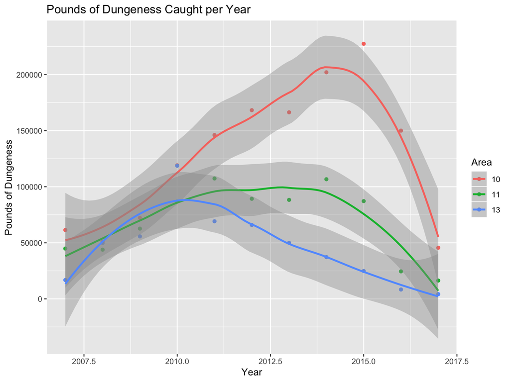

This graph uses the DC_catch_tidy dataframe.

## **Analysis**

Looking for trends within the main plot.

**Data subsets for analysis**

Subsets focus in on a particular part of the data showing a decline.

```r
lin_data.10 <- subset(DC_catch, year %in% c("2013", "2014", "2015", "2016", "2017"))
lin_data.11 <- subset(DC_catch, year %in% c("2014", "2015", "2016", "2017"))
lin_data.13 <- subset(DC_catch, year %in% c("2011", "2012", "2013", "2014",
                                            "2015", "2016", "2017"))
```

The data subset for area 10 focuses on 2013-2017, area 11 2014-2017, and area 13 2011-2017.

## **Linear models using subsets**

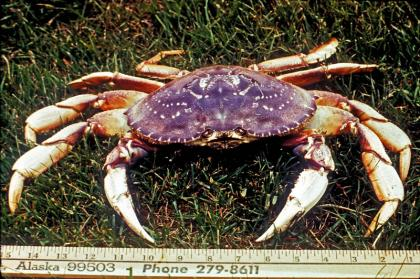

*C. magister*

All linear models are created using the DC_catch dataframe.

## **Liner model - Area 10**

```r
summary(lm_fit.10)
```

```
##
## Call:
## lm(formula = year ~ lbs_dungeness.10, data = lin_data.10)
##
## Residuals:
##       7       8       9      10      11
## -1.8788 -0.3428  1.0396  0.8757  0.3064
##
## Coefficients:
##                    Estimate Std. Error  t value Pr(>|t|)
## (Intercept)       2.017e+03  1.662e+00 1213.759 1.23e-09 ***
## lbs_dungeness.10 -1.503e-05  9.765e-06   -1.539    0.221
## ---
## Signif. codes:  0 '***' 0.001 '**' 0.01 '*' 0.05 '.' 0.1 ' ' 1
##
## Residual standard error: 1.365 on 3 degrees of freedom
## Multiple R-squared:  0.4411, Adjusted R-squared:  0.2548
## F-statistic: 2.368 on 1 and 3 DF,  p-value: 0.2215
```

## **Linear model - Area 11**

```r
summary(lm_fit.11)
```

```
##
## Call:
## lm(formula = year ~ lbs_dungeness.11, data = lin_data.11)
##
## Residuals:
##       8       9      10      11
## -0.1819  0.2826 -0.4380  0.3373
##
## Coefficients:
##                    Estimate Std. Error  t value Pr(>|t|)
## (Intercept)       2.017e+03  4.134e-01 4878.769  4.2e-08 ***
## lbs_dungeness.11 -2.746e-05  5.869e-06   -4.679   0.0428 *
## ---
## Signif. codes:  0 '***' 0.001 '**' 0.01 '*' 0.05 '.' 0.1 ' ' 1
##
## Residual standard error: 0.4575 on 2 degrees of freedom
## Multiple R-squared:  0.9163, Adjusted R-squared:  0.8744
## F-statistic: 21.89 on 1 and 2 DF,  p-value: 0.04277
```

## **Linear model - Area 13**

```r
summary(lm_fit.13)
```

```
##
## Call:
## lm(formula = year ~ lbs_dungeness.13, data = lin_data.13)
##
## Residuals:
##        5        6        7        8        9       10       11
## -0.36599  0.36305  0.05660  0.01241 -0.00593 -0.36081  0.30067
##
## Coefficients:
##                    Estimate Std. Error t value Pr(>|t|)
## (Intercept)       2.017e+03  2.169e-01 9300.90  < 2e-16 ***
## lbs_dungeness.13 -8.208e-05  4.898e-06  -16.76 1.38e-05 ***
## ---
## Signif. codes:  0 '***' 0.001 '**' 0.01 '*' 0.05 '.' 0.1 ' ' 1
##
## Residual standard error: 0.313 on 5 degrees of freedom
## Multiple R-squared:  0.9825, Adjusted R-squared:  0.979
## F-statistic: 280.9 on 1 and 5 DF,  p-value: 1.382e-05
```

## **Analysis findings**

Based off of the previously conducted linear models, there is no significant decrease in catch rate in marine area 10. However there is a significant decrease in areas 11 and 13.

## **Subset plots**

Shows a significant decrease in *C. magister* catch from 2014 to 2017.

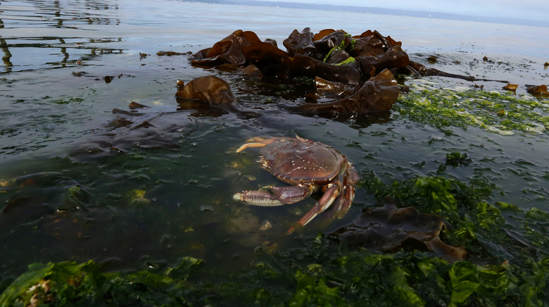

*C. magister* in a poor habitat

A new dataframe is created containing the estimated coefficients from the area 11 linear model previously conducted.

```r
fit.11 <- tidy(lm_fit.11)
```

| term | estimate | std.error | statistic | p.value |
| --- | --- | --- | --- | --- |
| (Intercept) | 2017.1113840 | 0.4134468 | 4878.769036 | 0.0000000 |
| lbs_dungeness.11 | -0.0000275 | 0.0000059 | -4.678723 | 0.0427725 |

A new dataframe is created containing the adjusted R^2 value from the area 11 linear model previously conducted.

```r
fit.11.R <- glance(lm_fit.11)
```

| r.squared | adj.r.squared | sigma | statistic | p.value | df | logLik | AIC | BIC | deviance | df.residual |
| --- | --- | --- | --- | --- | --- | --- | --- | --- | --- | --- |
| 0.9162845 | 0.8744268 | 0.4574808 | 21.89044 | 0.0427725 | 2 | -1.161379 | 8.322757 | 6.48164 | 0.4185774 | 2 |

## **Regression line dataframe for area 11 plot**

A new dataframe is created containing the predicted regression line points based off the area 11 regression line equation from linear model previous conducted.

```r
predicted.11 <- data.frame(catch_pred = predict(lm_fit.11, lin_data.11),
                           lbs_dungeness.11=lin_data.11$lbs_dungeness.11)
```

|  | catch_pred | lbs_dungeness.11 |
| --- | --- | --- |
| 8 | 2014.182 | 106686 |
| 9 | 2014.717 | 87185 |
| 10 | 2016.438 | 24524 |
| 11 | 2016.663 | 16341 |

## **Marine area 11 plot**

This graph shows a significant decrease in *C. magister* catch from 2014 to 2017.

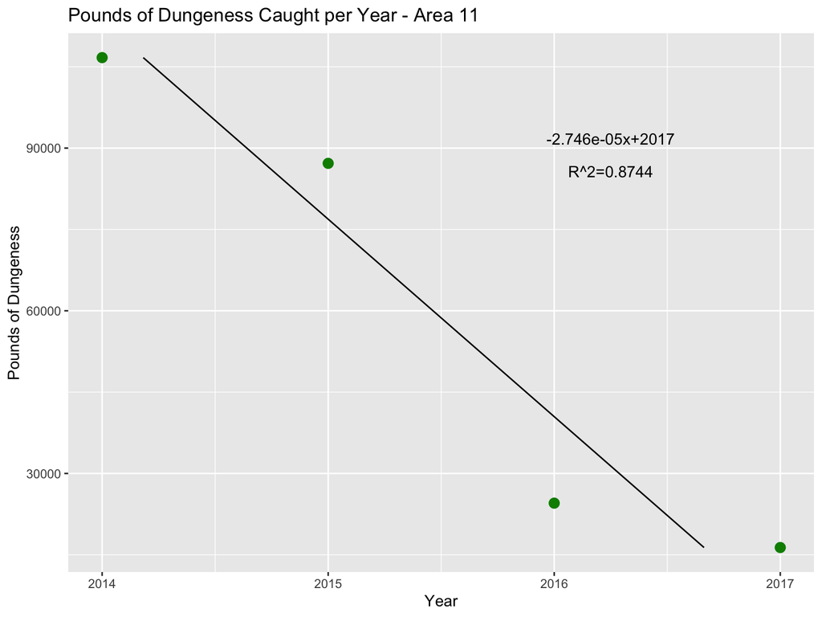

## **Linear model dataframes for area 13 plot - Coefficients**

A new dataframe is created containing the estimated coefficients from the area 13 linear model previously conducted.

```r
fit.13 <- tidy(lm_fit.13)
```

| term | estimate | std.error | statistic | p.value |
| --- | --- | --- | --- | --- |
| (Intercept) | 2017.0462140 | 0.2168658 | 9300.89459 | 0.00e+00 |
| lbs_dungeness.13 | -0.0000821 | 0.0000049 | -16.75913 | 1.38e-05 |

## **Linear model dataframes for area 13 plot - R squared values**

A new dataframe is created containing the R^2 value from the area 13 linear model previously conducted.

```r
fit.13.R <- glance(lm_fit.13)
```

| r.squared | adj.r.squared | sigma | statistic | p.value | df | logLik | AIC | BIC | deviance | df.residual |
| --- | --- | --- | --- | --- | --- | --- | --- | --- | --- | --- |
| 0.9825094 | 0.9790113 | 0.3129652 | 280.8683 | 1.38e-05 | 2 | -0.6232735 | 7.246547 | 7.084277 | 0.489736 | 5 |

## **Regression line dataframe for area 13 plot**

A new dataframe is created containing the predicted regression line points based off the area 13 regression line equation from the linear model previous conducted.

```r
predicted.13 <- data.frame(catch_pred = predict(lm_fit.13, lin_data.13),
                           lbs_dungeness.13=lin_data.13$lbs_dungeness.13)
```

|  | catch_pred | lbs_dungeness.13 |
| --- | --- | --- |
| 5 | 2011.366 | 69200 |
| 6 | 2011.637 | 65899 |
| 7 | 2012.943 | 49983 |
| 8 | 2013.988 | 37262 |
| 9 | 2015.006 | 24856 |
| 10 | 2016.361 | 8350 |

## **Marine area 13 plot**

This graph shows a significant decrease in *C. magister* catch from 2011 to 2017.

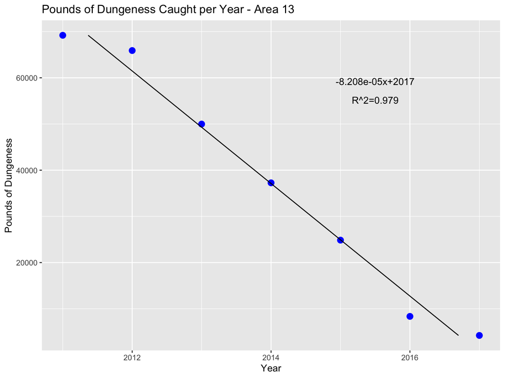